# Isoform Pattern Interpretation: NMD Inhibition Effects

Analysis Pipeline

2026-01-15

# 1 Analysis Overview

This report interprets isoform proportion patterns to understand the effects of NMD inhibition (Smg1i treatment) on transcript diversity across cell types.

**Research Questions:**

1. How does NMD inhibition affect the number of detected isoforms per gene?
2. What proportion of genes have a dominant isoform (>50% expression)?
3. What were the baseline (DMSO) proportions of transcripts that are upregulated by NMD inhibition?
4. Are these patterns consistent across cell types?
5. What proportion of transcriptional output is degraded by NMD at the gene level and within cell types?

# 2 Load Libraries

```r
library(tidyverse)
library(data.table)
library(DT)
library(edgeR)
```

# 3 Load Data

## 3.1 DGEList for Normalized Counts

```r
cat("Loading DGEList for normalized CPM values...\n")
```

```
## Loading DGEList for normalized CPM values...
```

```r
dge_isoform <- readRDS(INPUT_DGELIST)

cat("DGEList dimensions:", nrow(dge_isoform), "transcripts x", ncol(dge_isoform), "samples\n")
```

```
## DGEList dimensions: 299989 transcripts x 38 samples
```

```r
# Extract normalized CPM
cpm_normalized <- cpm(dge_isoform, normalized = TRUE, log = FALSE)
cat("Calculated normalized CPM\n\n")
```

```
## Calculated normalized CPM
```

**Note on Normalization:** All isoform proportions and expression analyses use normalized CPM values from the DGEList. This accounts for:

- Library size differences across samples
- Sequencing depth variations
- TMM normalization factors

This makes the isoform proportion analysis consistent with the differential expression analysis (limma-voom).

## 3.2 Calculate Isoform Proportions from Normalized CPM

```r
cat("Calculating isoform proportions from normalized CPM...\n")
```

```
## Calculating isoform proportions from normalized CPM...
```

```r
# Convert CPM matrix to long format with metadata
cpm_df <- as.data.frame(cpm_normalized)
cpm_df$transcript_id <- dge_isoform$genes$txid

cpm_long <- cpm_df %>%
  pivot_longer(cols = -transcript_id, names_to = "bamid", values_to = "cpm") %>%
  left_join(dge_isoform$samples %>% select(bamid, sample, treatment, ct),
            by = "bamid") %>%
  rename(cell_type = ct)

dge_isoform$genes$hgnc_id <- ifelse(is.na(dge_isoform$genes$hgnc_id.gc),
                                     dge_isoform$genes$hgnc_id.sq,
                                     dge_isoform$genes$hgnc_id.gc)

# Add gene information
cpm_long <- cpm_long %>%
  left_join(dge_isoform$genes %>% select(txid, hgnc_id),
            by = c("transcript_id" = "txid")) %>%
  rename(gene_id = hgnc_id)

# Calculate isoform proportions
all_proportions <- cpm_long %>%
  group_by(cell_type, treatment, sample, gene_id) %>%
  mutate(
    gene_total_cpm = sum(cpm),
    isoform_proportion = cpm / gene_total_cpm,
    isoform_proportion = ifelse(is.nan(isoform_proportion), 0, isoform_proportion),
    n_isoforms = n_distinct(transcript_id)
  ) %>%
  ungroup() %>%
  rename(normalized_cpm = cpm)

cat("Created proportion dataframe with", nrow(all_proportions), "rows\n")
```

```
## Created proportion dataframe with 11399582 rows
```

```r
cat("Cell types:", paste(unique(all_proportions$cell_type), collapse = ", "), "\n")
```

```
## Cell types: DD_ALI, DD, DO, AT, MV, FB
```

```r
cat("Treatments:", paste(unique(all_proportions$treatment), collapse = ", "), "\n\n")
```

```
## Treatments: Smg1i, DMSO
```

## 3.3 Apply Abundance Filter

To focus on more abundant isoforms and reduce noise from very low-expression transcripts, we apply a filter requiring **≥0.25 normalized CPM in at least one sample in EITHER DMSO or Smg1i** within each cell type.

```r
cat("Applying abundance filter (>=", CPM_THRESHOLD, " CPM in EITHER condition)...\n\n")
```

```
## Applying abundance filter (>= 0.25  CPM in EITHER condition)...
```

```r
# Load filtered isoform dictionary
filtered_dict <- readRDS(INPUT_FILTER_DICT)

cat("Loaded filtered isoform dictionary with", nrow(filtered_dict), "entries\n")
```

```
## Loaded filtered isoform dictionary with 1255256 entries
```

```r
cat("Unique isoforms:", n_distinct(filtered_dict$transcript_id), "\n\n")
```

```
## Unique isoforms: 299989
```

```r
# Show before filtering
before_stats <- all_proportions %>%
  group_by(cell_type) %>%
  summarize(
    n_isoforms_before = n_distinct(transcript_id),
    n_genes_before = n_distinct(gene_id),
    .groups = "drop"
  )

# Apply filter
all_proportions_filtered <- all_proportions %>%
  inner_join(
    filtered_dict %>% select(cell_type, transcript_id),
    by = c("cell_type", "transcript_id")
  )

# Show after filtering
after_stats <- all_proportions_filtered %>%
  group_by(cell_type) %>%
  summarize(
    n_isoforms_after = n_distinct(transcript_id),
    n_genes_after = n_distinct(gene_id),
    .groups = "drop"
  )

# Combine statistics
filter_stats <- before_stats %>%
  left_join(after_stats, by = "cell_type") %>%
  mutate(
    isoforms_removed = n_isoforms_before - n_isoforms_after,
    pct_isoforms_retained = 100 * n_isoforms_after / n_isoforms_before,
    genes_removed = n_genes_before - n_genes_after,
    pct_genes_retained = 100 * n_genes_after / n_genes_before
  )

cat("Filter results by cell type:\n\n")
```

```
## Filter results by cell type:
```

```r
print(filter_stats)
```

```
## # A tibble: 6 × 9
##   cell_type n_isoforms_before n_genes_before n_isoforms_after n_genes_after
##   <chr>                 <int>          <int>            <int>         <int>
## 1 AT                   299989          71592           211096         57257
## 2 DD                   299989          71592           226456         59572
## 3 DD_ALI               299989          71592           224654         59670
## 4 DO                   299989          71592           222537         59513
## 5 FB                   299989          71592           182004         51871
## 6 MV                   299989          71592           188509         52979
## # ℹ 4 more variables: isoforms_removed <int>, pct_isoforms_retained <dbl>,
## #   genes_removed <int>, pct_genes_retained <dbl>
```

```r
cat("\n")
```

```r
# Use filtered data for all downstream analyses
all_proportions <- all_proportions_filtered

cat("After filtering:", nrow(all_proportions), "rows\n")
```

```
## After filtering: 7984448 rows
```

```r
cat("Unique isoforms:", n_distinct(all_proportions$transcript_id), "\n")
```

```
## Unique isoforms: 299989
```

```r
cat("Unique genes:", n_distinct(all_proportions$gene_id), "\n\n")
```

```
## Unique genes: 71592
```

**Rationale for 0.25 CPM threshold:**

- Retains ~98% of statistically significant isoforms from DGE analysis
- Filters out very low-abundance transcripts that dominate the dataset but have minimal biological signal
- Reduces computational burden and focuses interpretation on more reliably detected isoforms

## 3.4 Isoform DGE Results

```r
# Read longread DGE results for each cell type
dge_files <- list.files(INPUT_DGE_DIR, pattern = DGE_FILE_PATTERN, full.names = TRUE)

cat("Loading", length(dge_files), "DGE result files...\n")
```

```
## Loading 6 DGE result files...
```

```r
all_dge <- map_df(dge_files, ~{
  df <- read_csv(.x, show_col_types = FALSE)

  # Extract cell type from filename
  basename <- basename(.x)
  parts <- str_split(basename, "_")[[1]]
  celltype <- parts[3]

  df$cell_type_file <- celltype
  df
})

# Map cell type codes to match proportion data
# Note: DO cells were only cultured at ALI, so doali maps to DO
all_dge$cell_type <- CELLTYPE_MAP[all_dge$cell_type_file]

# Filter out any unmapped cell types
all_dge <- all_dge %>% filter(!is.na(cell_type))

cat("Loaded", nrow(all_dge), "DGE results\n")
```

```
## Loaded 1749390 DGE results
```

```r
cat("Cell types:", paste(unique(all_dge$cell_type), collapse = ", "), "\n\n")
```

```
## Cell types: AT, DD, DD_ALI, DO, FB, MV
```

# 4 Q1: Isoforms Per Gene

**Question:** Does NMD inhibition reveal more isoforms per gene?

```r
# Count isoforms with non-zero normalized CPM per gene per treatment per cell type
# Detection threshold: normalized_cpm > 0 (most lenient, equivalent to any detection)
isoforms_per_gene <- all_proportions %>%
  filter(normalized_cpm > 0) %>%
  group_by(cell_type, treatment, gene_id) %>%
  summarize(
    n_isoforms_detected = n_distinct(transcript_id),
    .groups = "drop"
  )

# Compare DMSO vs Smg1i
isoform_comparison <- isoforms_per_gene %>%
  pivot_wider(
    names_from = treatment,
    values_from = n_isoforms_detected,
    values_fill = 0
  ) %>%
  mutate(
    delta_isoforms = Smg1i - DMSO,
    more_tx_smg1i = delta_isoforms > 0,
    fewer_tx_smg1i = delta_isoforms < 0,
    same_tx_count = delta_isoforms == 0
  )

# Summary statistics
q1_summary <- isoform_comparison %>%
  group_by(cell_type) %>%
  summarize(
    n_genes = n(),
    mean_dmso = mean(DMSO),
    mean_smg1i = mean(Smg1i),
    mean_delta = mean(delta_isoforms),
    genes_with_more_tx_smg1i = sum(more_tx_smg1i),
    genes_with_fewer_tx_smg1i = sum(fewer_tx_smg1i),
    genes_with_same_tx_count = sum(same_tx_count),
    pct_more_tx_smg1i = 100 * sum(more_tx_smg1i) / n(),
    .groups = "drop"
  )

cat("\n## Summary: Isoforms Per Gene by Cell Type\n\n")
```

```
##
## ## Summary: Isoforms Per Gene by Cell Type
```

```r
datatable(q1_summary,
          options = list(pageLength = 10),
          caption = "Average isoforms per gene in DMSO vs Smg1i") %>%
  formatRound(columns = c("mean_dmso", "mean_smg1i", "mean_delta", "pct_more_tx_smg1i"), digits = 2)
```

|  | cell_type | n_genes | mean_dmso | mean_smg1i | mean_delta | genes_with_more_tx_smg1i | genes_with_fewer_tx_smg1i | genes_with_same_tx_count | pct_more_tx_smg1i |
| --- | --- | --- | --- | --- | --- | --- | --- | --- | --- |
| 1 | AT | 57257 | 3.452136856628884 | 3.568105209843338 | 0.1159683532144541 | 8007 | 3848 | 45402 | 13.98431632813455 |
| 2 | DD | 59572 | 3.667545155442154 | 3.750721815618076 | 0.08317666017592157 | 5464 | 2013 | 52095 | 9.172094272477002 |
| 3 | DD_ALI | 59670 | 3.576537623596447 | 3.678481649069884 | 0.1019440254734372 | 7153 | 3158 | 49359 | 11.98759845818669 |
| 4 | DO | 59513 | 3.665972140540722 | 3.637457362256986 | -0.02851477828373633 | 2978 | 4193 | 52342 | 5.003948717087023 |
| 5 | FB | 51871 | 3.230629831697866 | 3.422721752038711 | 0.1920919203408455 | 8860 | 2361 | 40650 | 17.08083514873436 |
| 6 | MV | 52979 | 3.369165140904887 | 3.44160893939108 | 0.07244379848619265 | 6198 | 3751 | 43030 | 11.69897506559203 |

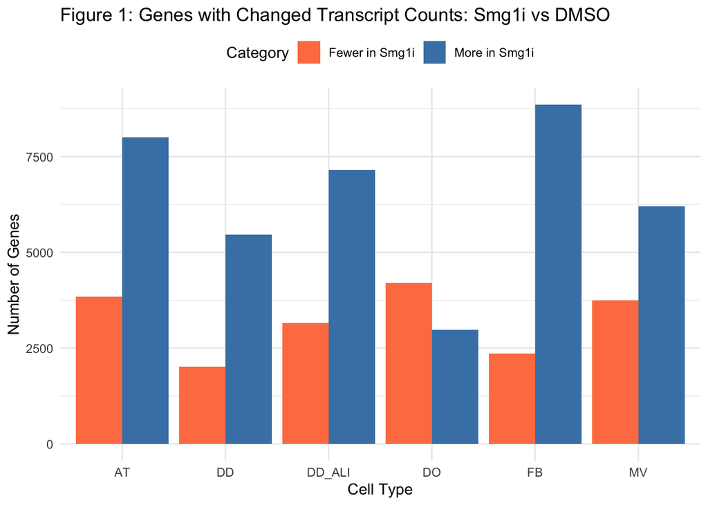

```r
# Distribution plot - Bar chart of categories (changed genes only)
category_summary <- isoform_comparison %>%
  mutate(category = case_when(
    more_tx_smg1i ~ "More in Smg1i",
    fewer_tx_smg1i ~ "Fewer in Smg1i",
    same_tx_count ~ "Unchanged"
  )) %>%
  count(cell_type, category) %>%
  filter(category != "Unchanged")

ggplot(category_summary, aes(x = cell_type, y = n, fill = category)) +
  geom_col(position = "dodge") +
  scale_fill_manual(values = c("More in Smg1i" = "steelblue",
                                "Fewer in Smg1i" = "coral")) +
  labs(title = "Figure 1: Genes with Changed Transcript Counts: Smg1i vs DMSO",
       x = "Cell Type",
       y = "Number of Genes",
       fill = "Category") +
  theme_minimal() +
  theme(legend.position = "top")
```

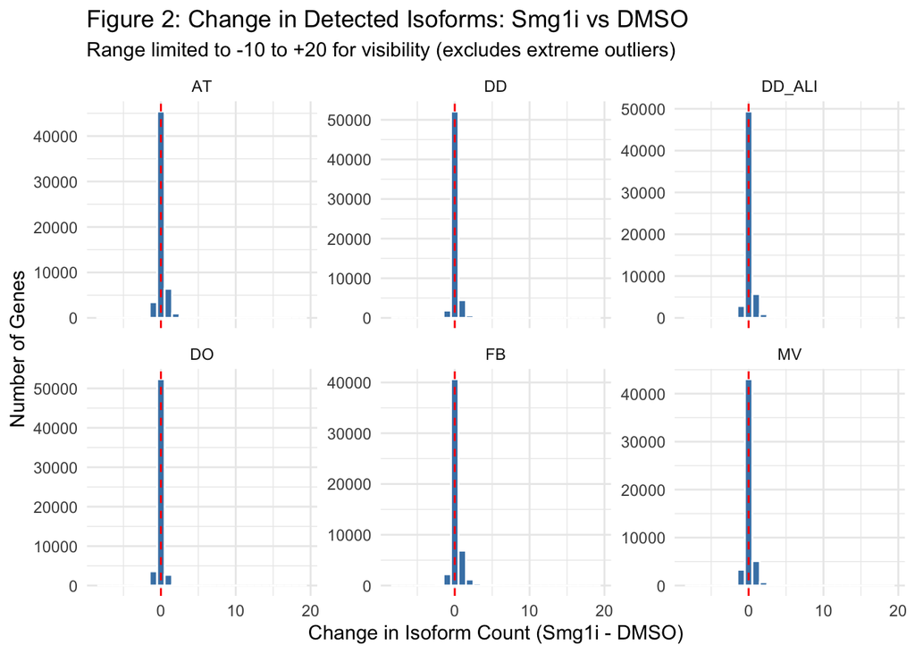

```r
# Distribution plot - Histogram (limited range for visibility)
ggplot(isoform_comparison %>% filter(delta_isoforms >= -10 & delta_isoforms <= 20),
       aes(x = delta_isoforms)) +
  geom_histogram(binwidth = 1, fill = "steelblue", color = "white") +
  facet_wrap(~cell_type, scales = "free_y") +
  geom_vline(xintercept = 0, linetype = "dashed", color = "red") +
  labs(title = "Figure 2: Change in Detected Isoforms: Smg1i vs DMSO",
       subtitle = "Range limited to -10 to +20 for visibility (excludes extreme outliers)",
       x = "Change in Isoform Count (Smg1i - DMSO)",
       y = "Number of Genes") +
  theme_minimal()
```

```r
# Save results
write_tsv(isoform_comparison, OUTPUT_Q1)
cat("\nSaved:", OUTPUT_Q1, "\n")
```

```
##
## Saved: ../tmp/isoform_interpretation_q1_isoforms_per_gene_2026.1.3.tsv
```

# 5 Q2: Dominant Isoforms

**Question:** How common are dominant isoforms (>50% of gene expression)?

**Analysis Scope:** This analysis is limited to genes with **3 or more isoforms**, as the concept of a “dominant isoform” is most relevant when multiple isoforms are present.

**Definition of Dominant Isoform:** For each gene in a specific cell type and treatment group, we identify the isoform with the highest average expression (normalized CPM) across all samples in that group. This isoform is considered **dominant** if it accounts for **>50% of the total normalized read counts** of its parent gene in **ALL samples** from that cell type/treatment group.

**Calculation:** - For each gene in each cell type/treatment group: 1. Calculate `isoform_proportion = isoform_CPM / sum(all_isoforms_CPM_for_gene)` in each sample 2. Identify which isoform has the highest average proportion across samples 3. Check if this isoform has proportion >0.5 in ALL samples 4. The gene has a “dominant isoform” only if one isoform meets this criterion

```r
# For each gene in each cell type/treatment, find if there's a consistently dominant isoform
# (i.e., one isoform that is >50% in ALL samples)

# First, get proportions for all isoforms
isoform_props <- all_proportions %>%
  filter(normalized_cpm > 0) %>%
  select(cell_type, treatment, sample, gene_id, transcript_id, isoform_proportion)

# Identify genes with 3+ isoforms in each cell type/treatment
genes_with_3plus_isoforms <- isoform_props %>%
  group_by(cell_type, treatment, gene_id) %>%
  summarize(n_isoforms = n_distinct(transcript_id), .groups = "drop") %>%
  filter(n_isoforms >= 3)

cat("Genes with 3+ isoforms by cell type and treatment:\n\n")
```

```
## Genes with 3+ isoforms by cell type and treatment:
```

```r
genes_3plus_summary <- genes_with_3plus_isoforms %>%
  group_by(cell_type, treatment) %>%
  summarize(n_genes_3plus = n(), .groups = "drop")
print(genes_3plus_summary)
```

```
## # A tibble: 12 × 3
##    cell_type treatment n_genes_3plus
##    <chr>     <chr>             <int>
##  1 AT        DMSO              16125
##  2 AT        Smg1i             16553
##  3 DD        DMSO              17221
##  4 DD        Smg1i             17512
##  5 DD_ALI    DMSO              17086
##  6 DD_ALI    Smg1i             17482
##  7 DO        DMSO              17461
##  8 DO        Smg1i             17349
##  9 FB        DMSO              13856
## 10 FB        Smg1i             14485
## 11 MV        DMSO              14593
## 12 MV        Smg1i             14794
```

```r
cat("\n")
```

```r
# Show isoform distribution (number of isoforms per gene)
isoform_dist <- isoform_props %>%
  group_by(cell_type, treatment, gene_id) %>%
  summarize(n_isoforms = n_distinct(transcript_id), .groups = "drop")

# Calculate break point for y-axis (2-isoform genes account for 95% of bottom range)
isoform_counts <- isoform_dist %>%
  filter(n_isoforms <= 10) %>%
  count(cell_type, treatment, n_isoforms)

max_2_isoform <- isoform_counts %>%
  filter(n_isoforms == 2) %>%
  pull(n) %>%
  max()

# Set bottom section upper limit so 2-isoform peak is at 95% of range
bottom_limit <- max_2_isoform / 0.95
# Break starts slightly above bottom limit, top section starts well above (e.g., where 1-isoform genes begin)
max_overall <- isoform_counts %>% pull(n) %>% max()
break_start <- bottom_limit * 1.05
break_end <- max_overall * 0.5  # Start top section around middle of 1-isoform peak

cat("Y-axis break: bottom section 0 -", round(bottom_limit),
    ", break at", round(break_start), "-", round(break_end), "\n\n")
```

```
## Y-axis break: bottom section 0 - 7052 , break at 7404 - 17438
```

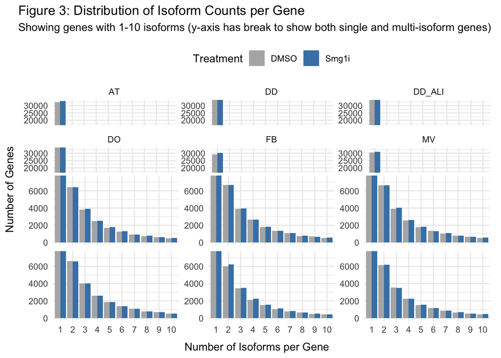

```r
# Install ggbreak if needed
if (!require("ggbreak", quietly = TRUE)) {
  options(repos = c(CRAN = "https://cloud.r-project.org"))
  install.packages("ggbreak")
  library(ggbreak)
}

# Plot isoform distribution with broken y-axis
ggplot(isoform_dist %>% filter(n_isoforms <= 10),
       aes(x = factor(n_isoforms), fill = treatment)) +
  geom_bar(position = "dodge") +
  facet_wrap(~cell_type, scales = "free_y") +
  scale_y_break(c(break_start, break_end), scales = 0.5) +
  scale_fill_manual(values = c("DMSO" = "gray70", "Smg1i" = "steelblue")) +
  labs(title = "Figure 3: Distribution of Isoform Counts per Gene",
       subtitle = "Showing genes with 1-10 isoforms (y-axis has break to show both single and multi-isoform genes)",
       x = "Number of Isoforms per Gene",
       y = "Number of Genes",
       fill = "Treatment") +
  theme_minimal() +
  theme(legend.position = "top")
```

```r
# Filter to genes with 3+ isoforms for dominant isoform analysis
isoform_props <- isoform_props %>%
  semi_join(genes_with_3plus_isoforms, by = c("cell_type", "treatment", "gene_id"))

# For each gene/cell type/treatment, check if any isoform is >50% in ALL samples
dominant_genes <- isoform_props %>%
  group_by(cell_type, treatment, gene_id, transcript_id) %>%
  summarize(
    n_samples = n(),
    n_dominant_samples = sum(isoform_proportion > 0.5),
    mean_proportion = mean(isoform_proportion),
    min_proportion = min(isoform_proportion),
    .groups = "drop"
  ) %>%
  # An isoform is dominant if it's >50% in ALL samples for this gene
  mutate(is_dominant_all_samples = n_dominant_samples == n_samples & n_samples > 0) %>%
  # For each gene, check if ANY isoform meets the criterion
  group_by(cell_type, treatment, gene_id) %>%
  summarize(
    n_isoforms = n(),
    has_dominant_isoform = any(is_dominant_all_samples),
    max_mean_proportion = max(mean_proportion),
    .groups = "drop"
  )

# Summarize by cell type and treatment
q2_summary <- dominant_genes %>%
  group_by(cell_type, treatment) %>%
  summarize(
    n_genes = n(),
    n_with_dominant = sum(has_dominant_isoform),
    pct_with_dominant = 100 * n_with_dominant / n_genes,
    mean_top_proportion = mean(max_mean_proportion),
    .groups = "drop"
  ) %>%
  arrange(cell_type, treatment)

cat("\n## Summary: Genes with Dominant Isoforms\n\n")
```

```
##
## ## Summary: Genes with Dominant Isoforms
```

```r
cat("**Table interpretation:**\n")
```

```
## **Table interpretation:**
```

```r
cat("- `n_genes`: Total genes analyzed in this cell type/treatment\n")
```

```
## - `n_genes`: Total genes analyzed in this cell type/treatment
```

```r
cat("- `n_with_dominant`: Genes where one isoform is >50% in ALL samples\n")
```

```
## - `n_with_dominant`: Genes where one isoform is >50% in ALL samples
```

```r
cat("- `pct_with_dominant`: Percentage of genes with a consistently dominant isoform\n")
```

```
## - `pct_with_dominant`: Percentage of genes with a consistently dominant isoform
```

```r
cat("- `mean_top_proportion`: Average proportion of the top isoform across genes\n\n")
```

```
## - `mean_top_proportion`: Average proportion of the top isoform across genes
```

```r
datatable(q2_summary,
          options = list(pageLength = 12),
          caption = "Genes with dominant isoform: one isoform accounts for >50% in ALL samples") %>%
  formatRound(columns = c("pct_with_dominant", "mean_top_proportion"), digits = 2)
```

|  | cell_type | treatment | n_genes | n_with_dominant | pct_with_dominant | mean_top_proportion |
| --- | --- | --- | --- | --- | --- | --- |
| 1 | AT | DMSO | 16125 | 7389 | 45.82325581395349 | 0.6016171891263193 |
| 2 | AT | Smg1i | 16553 | 6845 | 41.35202078173141 | 0.5727962854964718 |
| 3 | DD | DMSO | 17221 | 6555 | 38.06399163811626 | 0.5760252423918995 |
| 4 | DD | Smg1i | 17512 | 5512 | 31.47555961626313 | 0.5352198031224022 |
| 5 | DD_ALI | DMSO | 17086 | 7532 | 44.08287486831324 | 0.5888982466320992 |
| 6 | DD_ALI | Smg1i | 17482 | 7661 | 43.82221713762728 | 0.585756511198 |
| 7 | DO | DMSO | 17461 | 7414 | 42.46034018670179 | 0.5869090007310542 |
| 8 | DO | Smg1i | 17349 | 7188 | 41.43178281168944 | 0.5730471946172048 |
| 9 | FB | DMSO | 13856 | 6695 | 48.31841801385681 | 0.6264279793355548 |
| 10 | FB | Smg1i | 14485 | 6044 | 41.72592336900242 | 0.5882896461136181 |

[output cut: 2 more lines]

```r
# Compare DMSO vs Smg1i
q2_comparison <- q2_summary %>%
  select(cell_type, treatment, pct_with_dominant) %>%
  pivot_wider(names_from = treatment, values_from = pct_with_dominant) %>%
  mutate(delta_pct = Smg1i - DMSO)

cat("\n## Change in Dominant Isoform Prevalence\n\n")
```

```
##
## ## Change in Dominant Isoform Prevalence
```

```r
datatable(q2_comparison,
          options = list(pageLength = 10),
          caption = "% genes with dominant isoform: Smg1i vs DMSO") %>%
  formatRound(columns = c("DMSO", "Smg1i", "delta_pct"), digits = 2)
```

|  | cell_type | DMSO | Smg1i | delta_pct |
| --- | --- | --- | --- | --- |
| 1 | AT | 45.82325581395349 | 41.35202078173141 | -4.471235032222076 |
| 2 | DD | 38.06399163811626 | 31.47555961626313 | -6.588432021853123 |
| 3 | DD_ALI | 44.08287486831324 | 43.82221713762728 | -0.2606577306859634 |
| 4 | DO | 42.46034018670179 | 41.43178281168944 | -1.028557375012355 |
| 5 | FB | 48.31841801385681 | 41.72592336900242 | -6.592494644854398 |
| 6 | MV | 47.70095251147811 | 43.34865486007841 | -4.352297651399695 |

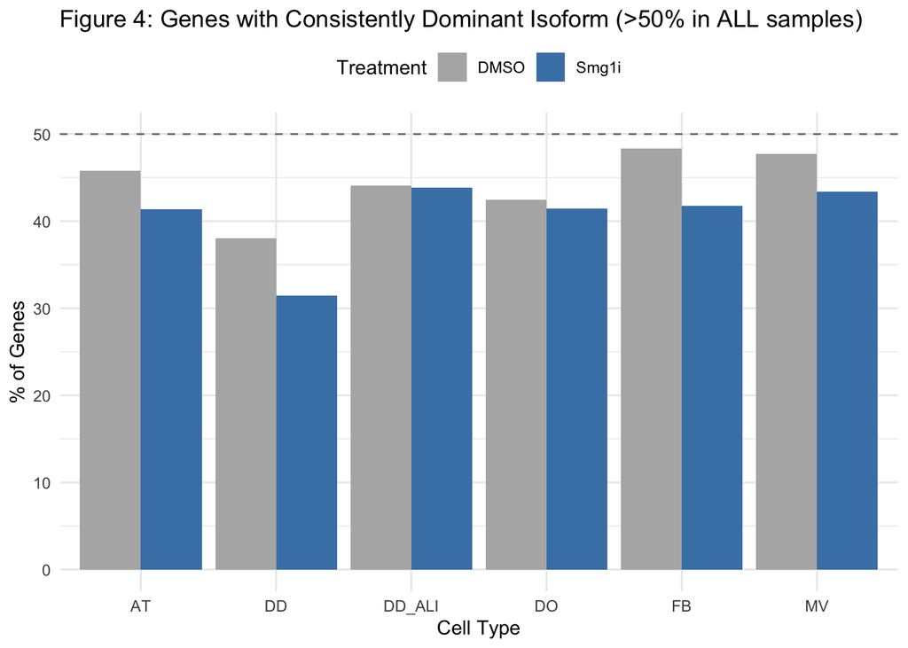

```r
# Visualization: Bar plot comparing dominant isoform prevalence
ggplot(q2_summary, aes(x = cell_type, y = pct_with_dominant, fill = treatment)) +
  geom_col(position = "dodge") +
  geom_hline(yintercept = 50, linetype = "dashed", color = "gray50") +
  scale_fill_manual(values = c("DMSO" = "gray70", "Smg1i" = "steelblue")) +
  labs(title = "Figure 4: Genes with Consistently Dominant Isoform (>50% in ALL samples)",
       x = "Cell Type",
       y = "% of Genes",
       fill = "Treatment") +
  theme_minimal() +
  theme(legend.position = "top")
```

```r
cat("\n## Relationship Between Isoform Count and Dominant Isoform Proportion\n\n")
```

```
##
## ## Relationship Between Isoform Count and Dominant Isoform Proportion
```

```r
# Calculate max proportion for each gene (excluding single-isoform genes)
# Use full proportions data before filtering to 3+ isoforms
max_proportion_by_gene <- all_proportions %>%
  filter(normalized_cpm > 0) %>%
  group_by(cell_type, treatment, sample, gene_id) %>%
  mutate(n_isoforms = n_distinct(transcript_id)) %>%
  filter(n_isoforms >= 2) %>%  # Exclude single-isoform genes
  # Find max proportion in each sample
  group_by(cell_type, treatment, sample, gene_id) %>%
  summarize(
    n_isoforms = first(n_isoforms),
    max_proportion = max(isoform_proportion),
    .groups = "drop"
  ) %>%
  # Average across samples for each gene
  group_by(cell_type, treatment, gene_id, n_isoforms) %>%
  summarize(
    mean_max_proportion = mean(max_proportion),
    .groups = "drop"
  )

cat("Genes included in analysis (≥2 isoforms):\n")
```

```
## Genes included in analysis (≥2 isoforms):
```

```r
max_prop_summary <- max_proportion_by_gene %>%
  group_by(cell_type, treatment) %>%
  summarize(
    n_genes = n(),
    mean_n_isoforms = mean(n_isoforms),
    mean_max_prop = mean(mean_max_proportion),
    .groups = "drop"
  )
print(max_prop_summary)
```

```
## # A tibble: 12 × 5
##    cell_type treatment n_genes mean_n_isoforms mean_max_prop
##    <chr>     <chr>       <int>           <dbl>         <dbl>
##  1 AT        DMSO        39814            7.30         0.612
##  2 AT        Smg1i       40189            7.71         0.592
##  3 DD        DMSO        47271            8.33         0.593
##  4 DD        Smg1i       45720            8.96         0.564
##  5 DD_ALI    DMSO        42006            7.81         0.608
##  6 DD_ALI    Smg1i       42381            7.99         0.604
##  7 DO        DMSO        42765            7.80         0.609
##  8 DO        Smg1i       41949            8.02         0.597
##  9 FB        DMSO        34597            6.81         0.629
## 10 FB        Smg1i       36140            7.29         0.609
## 11 MV        DMSO        35817            7.42         0.623
## 12 MV        Smg1i       36184            7.57         0.602
```

```r
cat("\n")
```

```r
# Diagnostic: Check data distribution for each cell type in the plot range
cat("Data check for Figure 4A (DMSO, 2-15 isoforms):\n")
```

```
## Data check for Figure 4A (DMSO, 2-15 isoforms):
```

```r
fig4a_data_check <- max_proportion_by_gene %>%
  filter(treatment == "DMSO", n_isoforms <= 15) %>%
  group_by(cell_type) %>%
  summarize(
    n_genes = n(),
    n_unique_isoform_counts = n_distinct(n_isoforms),
    min_isoforms = min(n_isoforms),
    max_isoforms = max(n_isoforms),
    range_max_prop = paste0(round(min(mean_max_proportion), 3), "-", round(max(mean_max_proportion), 3)),
    .groups = "drop"
  )
print(fig4a_data_check)
```

```
## # A tibble: 6 × 6
##   cell_type n_genes n_unique_isoform_counts min_isoforms max_isoforms
##   <chr>       <int>                   <int>        <int>        <int>
## 1 AT          35399                      14            2           15
## 2 DD          40596                      14            2           15
## 3 DD_ALI      36831                      14            2           15
## 4 DO          37549                      14            2           15
## 5 FB          31218                      14            2           15
## 6 MV          31711                      14            2           15
## # ℹ 1 more variable: range_max_prop <chr>
```

```r
cat("\n")
```

```r
# Check DD specifically
dd_check <- max_proportion_by_gene %>%
  filter(treatment == "DMSO", cell_type == "DD", n_isoforms <= 15) %>%
  group_by(n_isoforms) %>%
  summarize(n_genes = n(), .groups = "drop")
cat("DD gene counts by isoform number:\n")
```

```
## DD gene counts by isoform number:
```

```r
print(dd_check)
```

```
## # A tibble: 14 × 2
##    n_isoforms n_genes
##         <int>   <int>
##  1          2   11357
##  2          3    7298
##  3          4    5059
##  4          5    3692
##  5          6    2800
##  6          7    2124
##  7          8    1752
##  8          9    1441
##  9         10    1135
## 10         11     981
## 11         12     893
## 12         13     753
## 13         14     691
## 14         15     620
```

```r
cat("\n")
```

```r
# Check for data quality issues
data_quality_check <- max_proportion_by_gene %>%
  filter(treatment == "DMSO", n_isoforms <= 15) %>%
  group_by(cell_type) %>%
  summarize(
    n_genes = n(),
    n_na_prop = sum(is.na(mean_max_proportion)),
    n_inf_prop = sum(is.infinite(mean_max_proportion)),
    n_na_isoforms = sum(is.na(n_isoforms)),
    .groups = "drop"
  )
cat("Data quality check:\n")
```

```
## Data quality check:
```

```r
print(data_quality_check)
```

```
## # A tibble: 6 × 5
##   cell_type n_genes n_na_prop n_inf_prop n_na_isoforms
##   <chr>       <int>     <int>      <int>         <int>
## 1 AT          35399         0          0             0
## 2 DD          40596         0          0             0
## 3 DD_ALI      36831         0          0             0
## 4 DO          37549         0          0             0
## 5 FB          31218         0          0             0
## 6 MV          31711         0          0             0
```

```r
cat("\n")
```

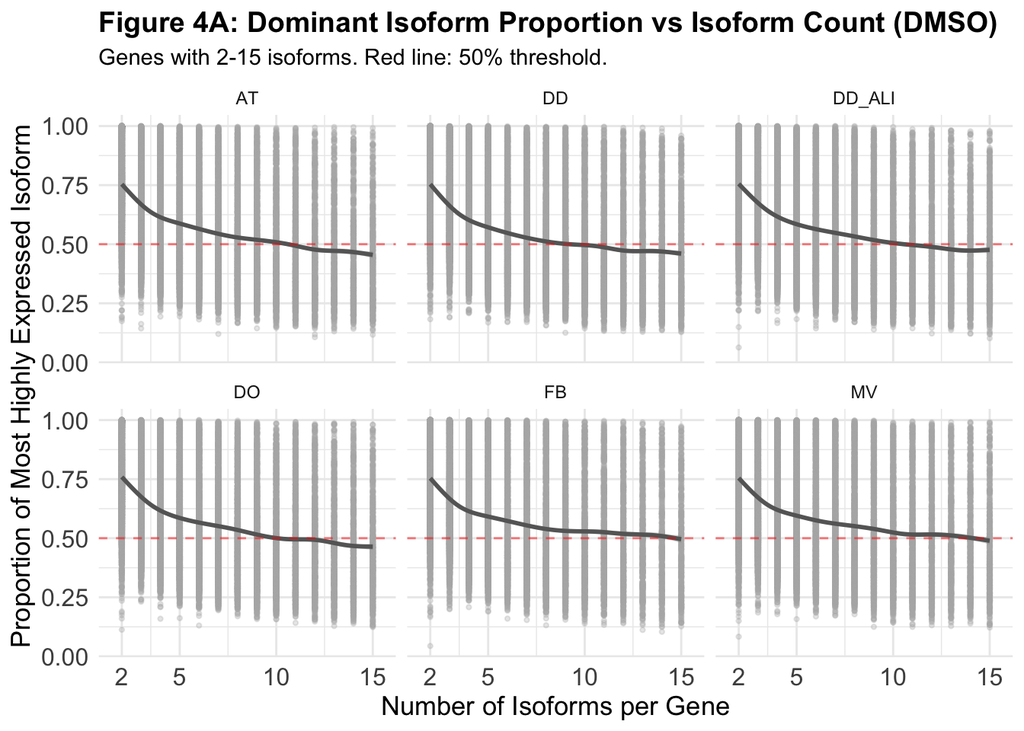

```r
# Plot: isoform count vs max proportion (DMSO only)
# Filter to 2-15 isoforms to focus on the biologically relevant range
ggplot(max_proportion_by_gene %>% filter(treatment == "DMSO", n_isoforms <= 15),
       aes(x = n_isoforms, y = mean_max_proportion)) +
  geom_point(alpha = 0.3, size = 0.8, color = "gray70") +
  geom_smooth(method = "gam", se = TRUE, linewidth = 1, color = "gray40") +
  facet_wrap(~cell_type) +
  scale_x_continuous(breaks = c(2, 5, 10, 15), limits = c(1.5, 15.5)) +
  geom_hline(yintercept = 0.5, linetype = "dashed", color = "red", alpha = 0.5) +
  labs(title = "Figure 4A: Dominant Isoform Proportion vs Isoform Count (DMSO)",
       subtitle = "Genes with 2-15 isoforms. Red line: 50% threshold.",
       x = "Number of Isoforms per Gene",
       y = "Proportion of Most Highly Expressed Isoform") +
  theme_minimal() +
  theme(
    axis.text = element_text(size = 12),
    axis.title = element_text(size = 13),
    plot.title = element_text(size = 14, face = "bold"),
    plot.subtitle = element_text(size = 11)
  )
```

```r
# Save results
write_tsv(q2_summary, OUTPUT_Q2)
cat("\nSaved:", OUTPUT_Q2, "\n")
```

```
##
## Saved: ../tmp/isoform_interpretation_q2_dominant_isoforms_2026.1.3.tsv
```

# 6 Q3: Baseline Proportions of NMD-Responsive Transcripts

**Question:** For NMD-responsive transcripts, what were their baseline (DMSO) proportions?

**Definition of NMD-Responsive Transcript:** Transcripts from the longread_dge differential expression analysis (Smg1i vs DMSO) that meet both criteria:

1. **logFC > 0**: Positive log fold change (higher expression in Smg1i compared to DMSO)
2. **adj.P.Val < 0.05**: Statistically significant after FDR correction

These transcripts are upregulated when the NMD pathway is inhibited with Smg1i treatment, indicating they are normally targeted for degradation by NMD. They represent classic NMD targets that are rescued by NMD inhibition. All analyses are stratified by cell type.

```r
# Identify NMD-responsive transcripts from DGE
# Definition: logFC > 0 (upregulated in Smg1i) AND adj.P.Val < 0.05 (statistically significant)
nmd_responsive <- all_dge %>%
  filter(logFC > 0, adj.P.Val < 0.05) %>%
  select(cell_type, transcript_id = txid, logFC, adj.P.Val)

cat("## NMD-Responsive Transcripts by Cell Type\n\n")
```

```
## ## NMD-Responsive Transcripts by Cell Type
```

```r
cat("**Note:** All Q3 analyses are stratified by cell type.\n\n")
```

```
## **Note:** All Q3 analyses are stratified by cell type.
```

```r
nmd_responsive_summary <- nmd_responsive %>%
  group_by(cell_type) %>%
  summarize(n_nmd_responsive = n(), .groups = "drop")

print(nmd_responsive_summary)
```

```
## # A tibble: 6 × 2
##   cell_type n_nmd_responsive
##   <chr>                <int>
## 1 AT                    6002
## 2 DD                   26358
## 3 DD_ALI               15841
## 4 DO                       1
## 5 FB                    2272
## 6 MV                    4581
```

```r
cat("\nTotal across all cell types:", nrow(nmd_responsive), "results\n")
```

```
##
## Total across all cell types: 55055 results
```

```r
cat("Unique transcripts (may appear in multiple cell types):", n_distinct(nmd_responsive$transcript_id), "\n\n")
```

```
## Unique transcripts (may appear in multiple cell types): 42559
```

```r
# Get baseline (DMSO) proportions for NMD-responsive transcripts
# CRITICAL: Do NOT filter by normalized_cpm > 0 here!
# We want to capture transcripts with ZERO DMSO expression (complete NMD rescue)
baseline_proportions <- all_proportions %>%
  filter(treatment == "DMSO") %>%
  inner_join(nmd_responsive, by = c("cell_type", "transcript_id")) %>%
  select(cell_type, sample, gene_id, transcript_id,
         normalized_cpm, isoform_proportion, n_isoforms, logFC, adj.P.Val)

cat("## Baseline Proportions Coverage\n\n")
```

```
## ## Baseline Proportions Coverage
```

```r
cat("**Why is baseline coverage missing for some NMD-responsive transcripts?**\n")
```

```
## **Why is baseline coverage missing for some NMD-responsive transcripts?**
```

```r
cat("NMD-responsive transcripts are identified from longread_dge statistical tests (all data),\n")
```

```
## NMD-responsive transcripts are identified from longread_dge statistical tests (all data),
```

```r
cat("but baseline proportions come from the filtered all_proportions dataset (>=0.25 CPM filter).\n")
```

```
## but baseline proportions come from the filtered all_proportions dataset (>=0.25 CPM filter).
```

```r
cat("Transcripts excluded by the abundance filter will not have baseline proportion data,\n")
```

```
## Transcripts excluded by the abundance filter will not have baseline proportion data,
```

```r
cat("even if they are statistically significant. These represent very low-abundance isoforms.\n\n")
```

```
## even if they are statistically significant. These represent very low-abundance isoforms.
```

```r
coverage_summary <- nmd_responsive %>%
  select(cell_type, transcript_id) %>%
  distinct() %>%
  left_join(
    baseline_proportions %>% select(cell_type, transcript_id) %>% distinct() %>% mutate(has_baseline = TRUE),
    by = c("cell_type", "transcript_id")
  ) %>%
  group_by(cell_type) %>%
  summarize(
    n_nmd_responsive = n(),
    n_with_baseline = sum(has_baseline, na.rm = TRUE),
    pct_coverage = 100 * n_with_baseline / n(),
    .groups = "drop"
  )

print(coverage_summary)
```

```
## # A tibble: 6 × 4
##   cell_type n_nmd_responsive n_with_baseline pct_coverage
##   <chr>                <int>           <int>        <dbl>
## 1 AT                    6002            5971         99.5
## 2 DD                   26358           25930         98.4
## 3 DD_ALI               15841           15609         98.5
## 4 DO                       1               1        100
## 5 FB                    2272            2267         99.8
## 6 MV                    4581            4561         99.6
```

```r
# Calculate overall coverage
total_nmd_responsive <- sum(coverage_summary$n_nmd_responsive)
total_with_baseline <- sum(coverage_summary$n_with_baseline)
overall_pct_coverage <- 100 * total_with_baseline / total_nmd_responsive

cat("\nTotal baseline proportions found for",
    n_distinct(baseline_proportions$transcript_id),
    "unique transcripts (",
    round(overall_pct_coverage, 1), "% overall coverage)\n\n")
```

```
##
## Total baseline proportions found for 41938 unique transcripts ( 98.7 % overall coverage)
```

```r
# Categorize by baseline expression level
baseline_categories <- baseline_proportions %>%
  mutate(
    baseline_category = case_when(
      normalized_cpm == 0 ~ "Zero (complete rescue)",
      normalized_cpm < 0.1 ~ "Low (< 0.1 CPM)",
      TRUE ~ "Moderate/High (≥ 0.1 CPM)"
    )
  )

cat("## Baseline Expression Categories\n\n")
```

```
## ## Baseline Expression Categories
```

```r
cat("Distribution of upregulated transcripts by DMSO baseline expression:\n")
```

```
## Distribution of upregulated transcripts by DMSO baseline expression:
```

```r
baseline_cat_summary <- baseline_categories %>%
  group_by(cell_type, baseline_category) %>%
  summarize(n = n(), .groups = "drop") %>%
  pivot_wider(names_from = baseline_category, values_from = n, values_fill = 0)

print(baseline_cat_summary)
```

```
## # A tibble: 6 × 4
##   cell_type `Low (< 0.1 CPM)` `Moderate/High (≥ 0.1 CPM)` Zero (complete rescu…¹
##   <chr>                 <int>                       <int>                  <int>
## 1 AT                     1048                        7316                   9549
## 2 DD                    16078                       38242                  49400
## 3 DD_ALI                 5697                       25898                  15232
## 4 DO                        0                           1                      2
## 5 FB                      580                        2852                   3369
## 6 MV                     1760                        7895                   4028
## # ℹ abbreviated name: ¹`Zero (complete rescue)`
```

```r
cat("\n")
```

```r
# Summary by cell type
# First, create transcript-level summaries (averaging across samples)
transcript_summary <- baseline_proportions %>%
  group_by(cell_type, transcript_id, gene_id, logFC, adj.P.Val) %>%
  summarize(
    mean_cpm = mean(normalized_cpm),
    mean_proportion = mean(isoform_proportion),
    n_samples = n(),
    n_zero_samples = sum(normalized_cpm == 0),
    .groups = "drop"
  ) %>%
  mutate(
    is_zero_all = n_zero_samples == n_samples,  # Zero in all samples
    is_low = mean_cpm > 0 & mean_cpm < 0.1,
    is_expressed = mean_cpm >= 0.1
  )

# Summarize by cell type
q3_summary <- transcript_summary %>%
  group_by(cell_type) %>%
  summarize(
    n_genes = n_distinct(gene_id),
    n_transcripts = n(),
    n_zero_dmso = sum(is_zero_all),  # Transcripts with zero in ALL samples
    n_low_dmso = sum(is_low),
    n_expressed_dmso = sum(is_expressed),
    pct_zero = 100 * n_zero_dmso / n(),
    pct_low = 100 * n_low_dmso / n(),
    mean_baseline_cpm = mean(mean_cpm[mean_cpm > 0]),
    median_baseline_cpm = median(mean_cpm[mean_cpm > 0]),
    mean_baseline_prop = mean(mean_proportion),
    median_baseline_prop = median(mean_proportion),
    pct_minor_isoforms = 100 * sum(mean_proportion < 0.5) / n(),
    pct_very_minor = 100 * sum(mean_proportion < 0.1) / n(),
    mean_logFC = mean(logFC),
    .groups = "drop"
  )

cat("## Summary: Baseline Proportions of NMD-Responsive Transcripts\n\n")
```

```
## ## Summary: Baseline Proportions of NMD-Responsive Transcripts
```

```r
cat("**Understanding the metrics and stratification:**\n\n")
```

```
## **Understanding the metrics and stratification:**
```

```r
cat("**Stratification:** All Q3 analyses are stratified by cell type. Each row in the table below represents one cell type.\n\n")
```

```
## **Stratification:** All Q3 analyses are stratified by cell type. Each row in the table below represents one cell type.
```

```r
cat("**Observation level:** The table summarizes unique NMD-responsive transcripts within each cell type.\n")
```

```
## **Observation level:** The table summarizes unique NMD-responsive transcripts within each cell type.
```

```r
cat("The raw data contains multiple observations per transcript (one per DMSO sample), but metrics are calculated at the transcript level by aggregating across samples.\n\n")
```

```
## The raw data contains multiple observations per transcript (one per DMSO sample), but metrics are calculated at the transcript level by aggregating across samples.
```

```r
cat("**Column definitions:**\n")
```

```
## **Column definitions:**
```